# Análisis exploratorio multivariante. Efecto del COVID-19 en el mercado financiero español

Gabriel Blanco, Sergio Cañón, Ignacio Ruiz de Zuazu.

09 octubre 2020

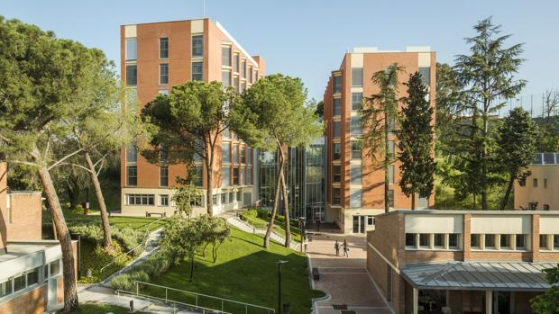

# 1. Motivación del análisis

El objetivo de esta investigación es averiguar, mediante una serie de contrastes y pruebas estadísticas, cuales han sido los efectos del coronavirus en los mercados financieros, concretamente en el mercado financiero español de acciones. Para dichos efectos, se construye una cartera de acciones del IBEX-35, y se utiliza este mismo índice como referencia, para comparar los activos de manera individual con el mercado. Para llevar a cabo los contrastes antes y después del COVID-19, se utiliza una variable categórica o “dummy”, con el fin de facilitar esta tarea.

# 2. Datos y variables

Los activos elegidos son aquellos a los cuales la crisis del coronavirus ha impactado con mayor virulencia:

- Amadeus: empresa de servicios tecnológicos para el sector del turismo.
- Meliá: grupo de hoteles.
- Cie Automotive: grupo de empresas del sector automotriz español:
- Inditex: sector textil y gran peso en el IBEX-35
- Santander: sector bancario, ya en declive desde antes del coronavirus.

Los datos utilizados son todos de tipo financiero, y en la mayoría de operaciones se analizan medidas correspondientes a los rendimientos diarios de los activos. Dichos rendimientos se calculan sobre el precio ajustado. El periodo analizado comienza el 24 de septiembre de 2019 y finaliza el 24 de septiembre de 2020. Se realizan distintos ajustes en el número de observaciones disponibles de cada activo, con el fin de tener un número constante que facilite el tratamiento. En este contexto, el total de observaciones con el que se termina trabajando es de 253 en el caso de las series de precios, y 252 una vez calculados los rendimientos.

Para los valores no disponibles, se imputa la media del rendimiento de su serie, con el fin de reducir el sesgo. Esta operacion se tuvo que realizar para Inditex, Meliá y Cie para los días 17 y 20 de julio de 2020. Para el caso del IBEX-35, la imputación corresponde a los días 24 y 25 de dicimebre de 2019.

La fuente de los datos es Yahoo Finnance

### Cálculo de los rendimientos

Se define una función para abreviar el proceso, y se ejecuta sobre las 6 series de precios ajustados.

El dataframe rendimientos es con el que se opera en la mayoría del trabajo. Esta es una muestra de sus 10 primeras filas

| Fechas | Ibex | Amadeus | Cie | Inditex | Melia | Santander |
| --- | --- | --- | --- | --- | --- | --- |
| 2019-09-24 | -0.0036082 | -0.0153847 | 0.0008953 | -0.0046696 | 0.0020950 | 0.0102301 |
| 2019-09-25 | 0.0048871 | 0.0000000 | -0.0017890 | 0.0068567 | -0.0236934 | -0.0050634 |
| 2019-09-26 | 0.0059585 | 0.0079658 | 0.0161291 | 0.0078854 | 0.0085653 | 0.0152672 |
| 2019-09-27 | 0.0065875 | -0.0012158 | 0.0141092 | 0.0099573 | 0.0077849 | 0.0075189 |
| 2019-09-30 | -0.0085130 | -0.0152161 | -0.0199998 | -0.0080986 | 0.0056180 | -0.0199006 |
| 2019-10-01 | -0.0276787 | -0.0429543 | -0.0133098 | -0.0312388 | -0.0167598 | -0.0304568 |
| 2019-10-02 | -0.0011221 | 0.0103327 | -0.0557554 | 0.0047636 | -0.0035511 | 0.0052357 |
| 2019-10-03 | 0.0066949 | 0.0150207 | 0.0000000 | 0.0142231 | 0.0049893 | 0.0000000 |
| 2019-10-04 | 0.0091834 | 0.0122796 | 0.0114285 | 0.0115067 | 0.0085106 | 0.0052081 |
| 2019-10-07 | -0.0114992 | -0.0037326 | 0.0047082 | -0.0223960 | -0.0028129 | -0.0129533 |

Esta es la tabla con la que se trabaja a lo largo de toda la investigación

# 3. Estadísticos descriptivos

Con el fin de tener una primera descripción de los rendimientos, se calculan algunos estadísticosdescriptivos, cuyos resultados aparecen resumidos en la siguiente tabla:

|  | Ibex | Amadeus | Cie | Inditex | Melia | Santander |
| --- | --- | --- | --- | --- | --- | --- |
| Mínimo | -14.06% | -16.10% | -14.89% | -10.53% | -18.51% | -18.82% |
| Media | -0.08% | -0.05% | -0.09% | -0.01% | -0.23% | -0.24% |
| Máximo | 7.82% | 14.93% | 11.00% | 12.24% | 26.58% | 10.00% |
| R. semi-intercuartílico | 0.008 | 0.012 | 0.015 | 0.011 | 0.017 | 0.015 |
| Desviación típica | 1.99% | 3.24% | 3.09% | 2.36% | 4.33% | 3.48% |
| Varianza | 0.000396 | 0.001047 | 0.000957 | 0.000559 | 0.001872 | 0.001209 |
| Exceso de Curtosis | 11.42 | 5.67 | 4.10 | 4.40 | 12.31 | 4.86 |
| Asimetría | -1.50 | 0.30 | -0.26 | 0.37 | 1.54 | -0.90 |
| C. de variación de Pearson | 24.27 | 68.12 | 33.18 | **163.33** | 19.04 | 14.64 |

Los estadísticos para la cartera equiponderada son los siguientes:

|  | **Rendimiento medio** | **Varianza** | **Desviación típica** | **Coeficiente de variación de Pearson** |
| --- | --- | --- | --- | --- |
| **Cartera equiponderda** | -0.1% | 0.001 | 3.3% | 33 |

# 4. Contraste de hipótesis

Se llevan a cabo un total de 4 contrastes de hipótesis:

- Shapiro test, para contrastar la hipotética normalidad de las distribuciones de los rendimientos
- t.test para antes y después del COVID-19, para contrastar el cambio en la media de los rendimietnos
- Test de varianza antes y después del COVID-19, para contrastar el efecto en la dispersión.
- Test de varianza entre los activos y el índice, para contrastar la diferencia entre las dispersiones de los activos y el índice.

Antes de profundizar en los contrases, se muestra una visualización previa del comportamiento del mercado en el periodo analizado.

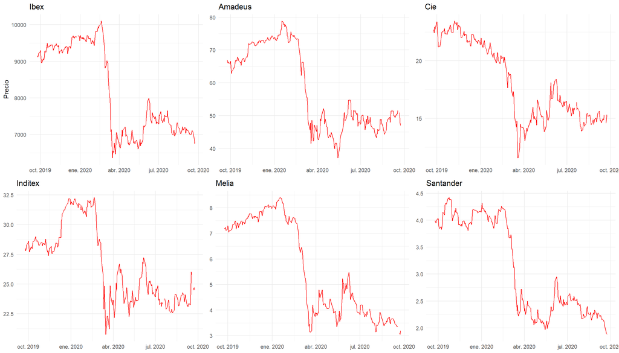

Se puede apreciar de manera clara el desplome generalizado de los activos en torno a la fecha del 9 de marzo de 2020. Dicho día es el que se toma como referencia para los contrastes entre los dos periodos.

### Contraste de normalidad: test de Shapiro Wilk

Para contrastar si los rendimientos provienen de una distribución normal, se realiza el test de Shapiro Wilk, con un nivel de significación del 5%. Este test establece como hipótesis nula la normalidad de la distribución de la población de la cual procede la muestra analizada.

|  | Ibex | Amadeus | Cie | Inditex | Melia | Santander |
| --- | --- | --- | --- | --- | --- | --- |
| Estadístico | 0.8636572 | 0.8923727 | 0.9360392 | 0.9353909 | 0.8126962 | 0.925936 |
| P. Valor | 3.637322e-14 | 2.069337e-12 | 5.291462e-09 | 4.60734e-09 | 1.001155e-16 | 6.702554e-10 |
| H<sub>0</sub> | Rechazo | Rechazo | Rechazo | Rechazo | Rechazo | Rechazo |

El p. valor que se obtiene para todas las variables contrastadas permite rechazar la normalidad en todos los casos. Se puede rechazar la normalidad de la distribución de la que proceden cada uno de los activos. Este hecho es característico de los rendimientos financieros, que habitualmente presentan distribuciones con “colas pesadas”.

### Contraste de varianzas: índice y activos.

El test para la varianza establece como hipótesis nula que el cociente de la varianza del primer grupo sobre la varianza del segundo grupo es igual a 1. Es decir, que ambas varianzas son estadísticamente iguales.

|  | Amadeus | Cie | Inditex | Melia | Santander |
| --- | --- | --- | --- | --- | --- |
| Estadístico F | 0.37841 | 0.41408 | 0.70875 | 0.21162 | 0.32767 |
| P. Valor | 4.465e-14 | 6.457e-12 | 0.006576 | < 2.2e-16 | < 2.2e-16 |
| Ratio de varianzas | 0.378 | 0.414 | 0.709 | 0.212 | 0.328 |
| Intervalo de confianza | (0.295 - 0.485) | (0.323 - 0.530) | (0.553 - 0.908 ) | (0.165 - 0.271) | (0.256 - 0.420) |
| H<sub>0</sub> | Rechazo | Rechazo | Rechazo | Rechazo | Rechazo |

En base a los p. valores obtenidos, es posible rechazar la igualdad de las varianzas de los activos y el IBEX-35. Este resultado es coherente con la realidad, puesto que una caracetrística de los activos individuales es presentar más riesgo que el mercado. Representado el mercado como un índice, en este caso el IBEX-35, cabe esperar que la dispersión del índice sea menor que la dispersión de sus activos, evaluados de forma individual. En otras palabras, los rendimientos de los activos presentan más riesgo, medido en forma de dispersión, que los rendimientos del mercado.

### Contraste de varianzas: antes y después del COVID-19.

Análogo al test anterior, establece como hipótesis nula la igualdad de varianzas entre los grupos evaluados. La diferencia es que en este caso, el contraste se hace para la varianza de cada variable, antes y después del coronavirus.

|  | Ibex | Amadeus | Cie | Inditex | Melia | Santander |
| --- | --- | --- | --- | --- | --- | --- |
| Estadístico F | 0.73746 | 0.32472 | 0.42841 | 0.41414 | 0.18066 | 0.90986 |
| P. Valor | 0.09162 | 1.357e-09 | 3.782e-06 | 1.577e-06 | < 2.2e-16 | 0.6009 |
| Ratio de varianzas | 0.737 | 0.325 | 0.428 | 0.414 | 0.180 | 0.910 |
| Intervalo de confianza | (0.519 - 1.050) | (0.228 - 0.463) | (0.301 - 0.610) | (0.291 - 0.590 ) | (0.127 - 0.257) | (0.640 - 1.297) |
| H<sub>0</sub> | **No rechazo** | Rechazo | Rechazo | Rechazo | Rechazo | **No rechazo** |

Es posible rechazar la igualdad de varianzas para todas las variables, excepto para el Ibex y Santander. Para el resto de variables, el test revela que el coronavirus ha impactado en la dispersion de sus rendimientos, haciendo que sean estadísticamente más dispersos después que antes del COVID-19. Es decir, que el efecto del virus en los mercados se ha reflejado en forma de mayor riesgo, puesto que los rendimientos después del punto del COVID-19 presentan mayor dispersión que aquellos del primer grupo.

Sin embargo, la hipótesis no se rechaza para el caso del Ibex y Santander. En cuanto al Ibex, cabría esperar que debido al tamaño del índice, el impacto del virus en términos de su varianza sea menos perceptible.

Respecto a Santander, el motivo quizá sea el estado de declive en el que se encuentra sumergido el sector bancario español desde hace tiempo. Bajo estas circunstancias, los efectos del virus no serían tan notables como sí lo son para el resto de variables analizadas.

### Contraste para la media: antes y después del COVID-19

[output not shown]

Por su parte, el t.test establece como hipótesis nula la igualdad de medias entre los grupos evaluados. En base a los p.valores que se obtienen de este contraste, no es posible rechazar la igualdad de media para los rendimientos antes y después del coronavirus. Pese a haber tenido un impacto en las varianzas, como se ha contrastado antes, el virus no ha supuesto diferencias estadísticamente significativas en la media de los rendimientos diarios.

# 5. Visualicaciones

El objetivo de esta seccion es exponer de manera gráfica algunos de los hechos estudiados en los contrastes

### Histogramas y estimadores Kernel

En referencia a la no normalidad de la distribución de los rendimientos, se realizan histogramas para cada variable, con sus estimadores Kernel.

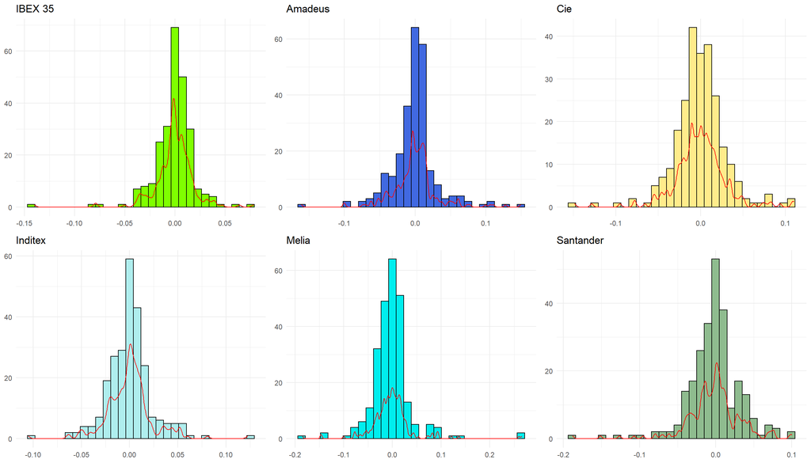

Las visualizaciones revelan como las distribuciones de los rendimientos no se asemejan a una distribución normal, tal y como se contrastó con el Shapiro test. Características de la normal, como que aproximadamente el 97% de las observaciones se encuentran en el intervalo entre [media mas menos 3 sd] no se cumplen en estos casos. En todas las variables estudiadas hay numerosos rendimientos que se salen de ese iintervalo de normalidad.

### Funciones de densidad comparativas con el IBEX-35

Se presenta de manera gráfica la diferencia entre las dispersiones de los activos y el índice.

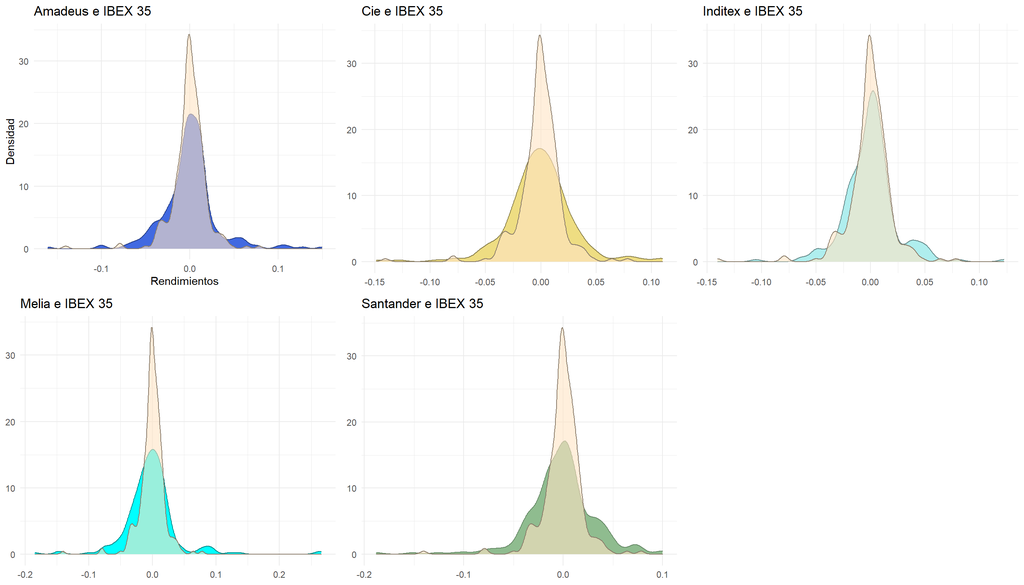

La densidad del IBEX-35 se grafica siempre en color claro. Se puede observar la diferencai en la dispersión de los rendimientos entre los activos y el índice, así como la diferencia en sus densidades en sentido amplio. Mientras que el IBEX-35 presenta una función de densidad más estrecha y concentrada en torno a la media, el resto de activos presentan densidades mas amplias y achatadas, menos centradas en la media.

### Gráficos de caja y bigotes: antes y después del COVID-19

Se emplean distintas combinaciones de diagrama de caja y bigotes para visualizar gráficamente el efecto del coronavirus en las distribuciones

En primer lugar, los diagramas por parejas. La parte izquierda representa las distribuciones antes del virus, y la derecha, después.

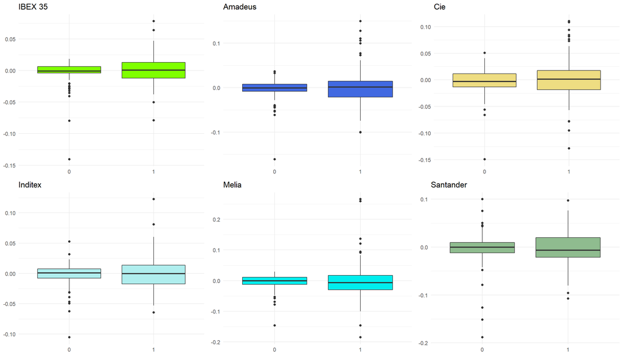

Se puede observar como en la mayoría de casos aumenta la dispersión, la distribución se hace más amplia y aparecen más valores extremos. No obstante, el defecto de esta visualizacion es que los activos no comparten el eje de ordenadas, algo que dificulta las comparaciones. Por este motivo, se incluyen también las dos siguientes visualizaciones en las que los activos sí que comparten el eje de ordenadas. La primera visualización corresponde al periodo previo, y la segunda al posterior.

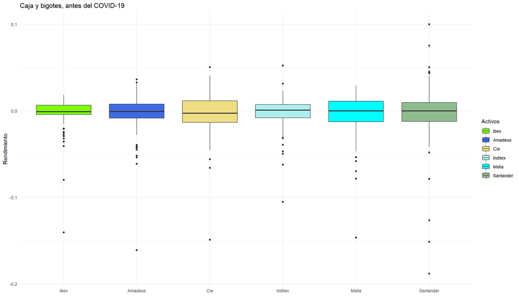

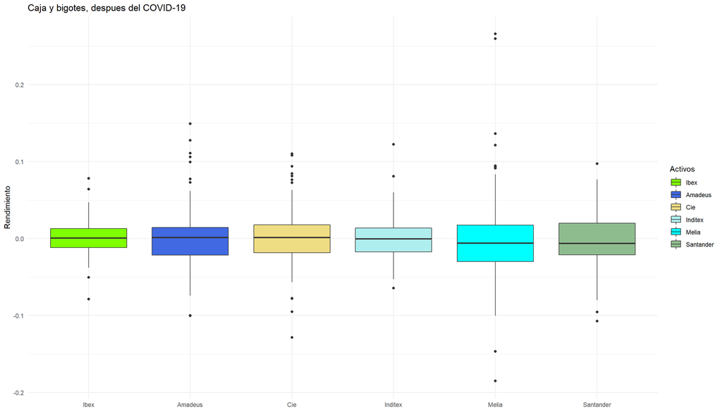

Nuevamente, se aprecia el aumento en la dispersión, un comportamiento común a todos los activos excepto a Santander, como se ha comentado previamente.

Sin embargo, estos diagramas, pese a ser útiles para arrojar una imagen rápida y descriptiva de las distribuciones, no son eficaces en cuanto a ilustrar la forma de los rendimientos. Es decir, no es posible visualizar como se concentran realmente los rendimientos. Establecen una serie de tramos que representan los cuartiles, pero no es posible visualizar la densidad de los datos, cuantos rendimientos hay en cada cuartil. Para estos fines, los diagramas de violines se ajustan mejor. A continuación se incluyen las mismas comparaciones visuales anteriores, pero hechas con diagramas de violines.

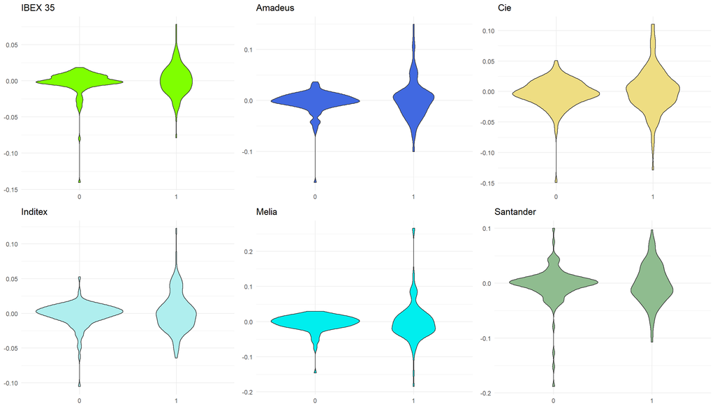

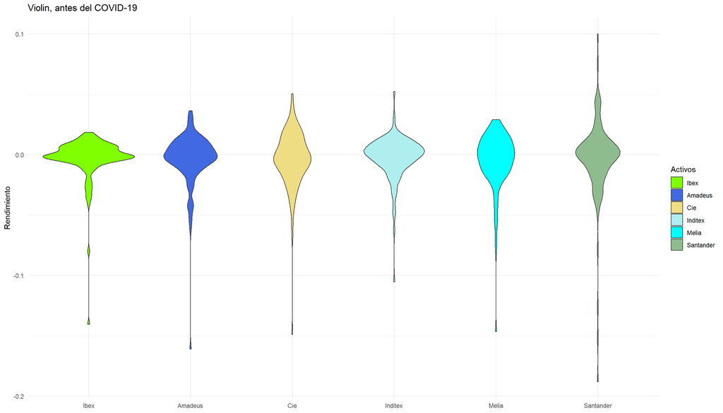

[figure not shown]

Con estas visualizaciones, el efecto del COVID-19 en las distribuciones queda retratado. Se aprecia de manera clara como las distribuciones se dispersan más respecto a la media, y como la densidad de rendimientos en torno a ella disminuye.

### Matriz de covarianzas y correlograma

|  | Ibex | Amadeus | Cie | Inditex | Melia | Santander |
| --- | --- | --- | --- | --- | --- | --- |
| Ibex | 1 | 0.71 | 0.56 | 0.79 | 0.63 | -0.11 |
| Amadeus | 0.71 | 1 | 0.54 | 0.53 | 0.56 | -0.08 |
| Cie | 0.56 | 0.54 | 1 | 0.43 | 0.55 | -0.11 |
| Inditex | 0.79 | 0.53 | 0.43 | 1 | 0.55 | -0.07 |
| Melia | 0.63 | 0.56 | 0.55 | 0.55 | 1 | 0.06 |
| Santander | -0.11 | -0.08 | -0.11 | -0.07 | 0.06 | 1 |

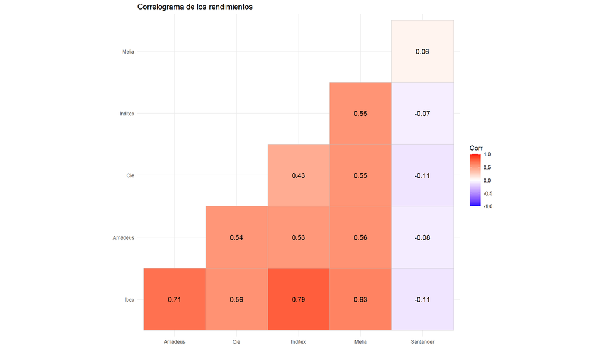

Los activos con mayor correlacion con el IBEX-35 son Inditex y Amadeus, con unos valores de 0.79 y 0.71 respectivamente. Análogamente, estos activos son los mismos que presetnaban una función de densidad de mayor semejanza a la del IBEX-35. Meliá también presenta una correlación importante, con un valor de 0.63. El activo que resulta estar menos correlacionado con el índcie es Santander, que presenta una correlación cercana a 0. Adicionalmente, es el activo que menor correlación presenta con los demás. Estos datos encajan con la asimetría percibida en los cambios en Santander respecto a los demás activos.

# 6. Capital Asset Pricing Model

Para finalizar la investigación, se construye el CAPM. Este es un modelo utilizado para calcular la rentabilidad que un inversor recibe de sus activos en base al riesgo soportado. Este modelo se basa en la teoría de selección de carteras de Harry Markowitz. El modelo en cuestión, describe la relación entre rendimiento esperado y riesgo del siguiente modo

$E(ri) = rf + Bi*(E(rm)-rf)$

- $E(ri)$ es la tasa de rendimiento esprado.
- $Bi$ es la beta, que captura la cantidad de riesgo con respecto a la cartera de mercado.
- $E(rm)-rf$ es la prima de riesgo del mercado rm es el rendimiento del mercado rf es un activo libre de riesgo.

Para el presente caso, se considera activo libre de riesgo al bono del tesoro español a 10 años. Para construir el modelo, se calculan las desviaciones típicas, los rendimientos y las betas de cada una de las variables.

Es conveniente mencionar algunos de los hechos que asume el modelo:

1. Los individuos son adversos al riesgo, y maximizan la utilidad de su riqueza en el próximo período. Es un modelo plurianual.
2. Los individuos no pueden afectar los precios, y tienen expectativas homogéneas respecto a las varianzascovarianzas y acerca de los retornos esperados de los activos.
3. El retorno de los activos, se distribuye de manera normal.
4. Existe un activo libre de riesgo, al cual los individuos pueden prestar y/o endeudarse en cantidades ilimitadas

Como la cartera construida es equiponderada, tanto el riesgo, la rentabilidad y la beta de sus componentes también lo están.

Se crea un objeto que contenga dichos datos de la cartera, y se pasa a unificar los datos en una tabla con los datos de los activos de manera individual.

En último término, se declara una función para el calculo de la Security Market Line, con el fin de compararla con los activos. Se toma como activo libre de riesgo el bono del tesoro español a 10 años, con un rendimiento del 0.25%, y la beta de la cartera previamente calculada, 0.82.

### Visualizaciones CAPM

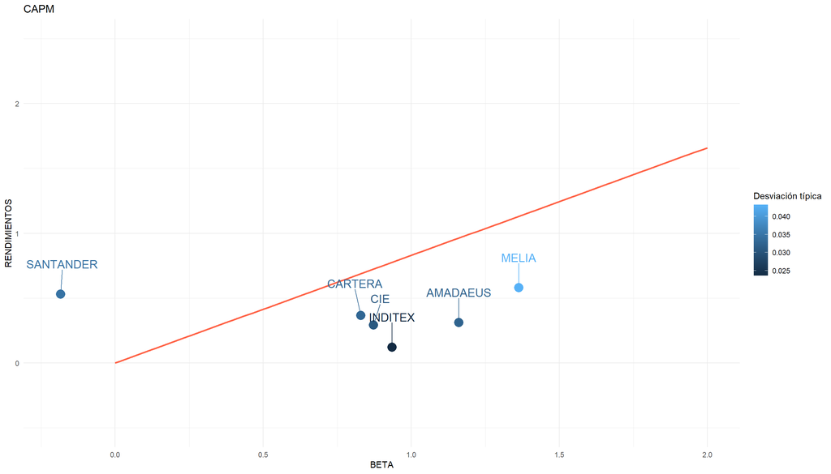

El resultado revela que la cartera seleccionada no es eficiente y todos los valores se encuentran infravalorados respecto al mercado por menor rentabilidad por reisgo asumido, a excepción del Santander.

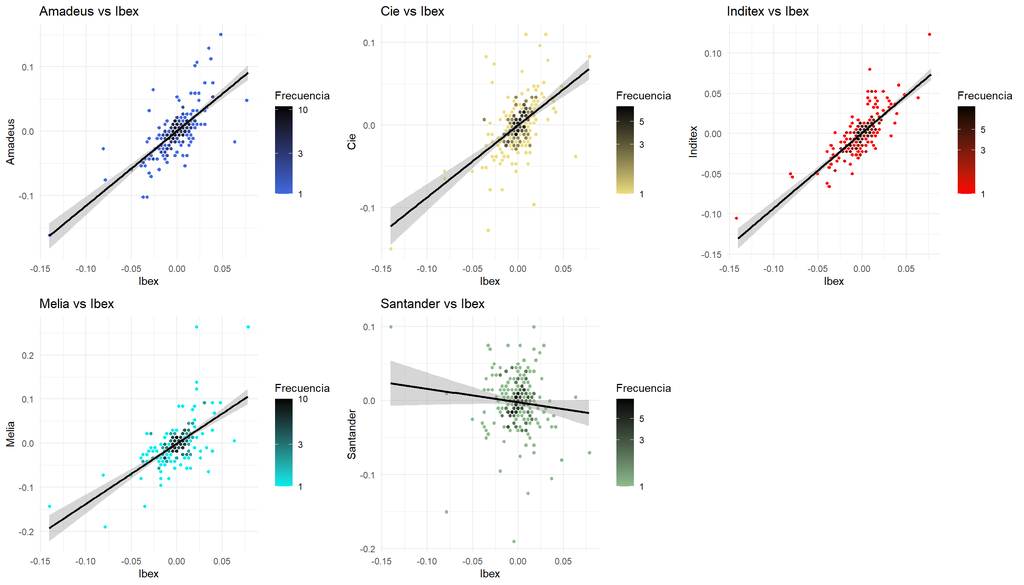

Esta última visualizacion constituye un resumen de la sección del CAPM. La pendiente de los rendimientos del Santander respecto a los del IBEX-35 es negativa, un indicador de su beta negativa. Del resto decir simplemente que son similares al Ibex

### Problemas del CAPM.

Conviene mencionar que pese a su fama, este modelo cuenta con numerosos inconvenientes que lo alejan de ser realista.

En primer lugar, el modelo no explica adecuadamente la variación en los retornos de los títulos valores. Estudios empíricos muestran que activos con bajos betas pueden ofrecer retornos más altos de los que el modelo sugiere.

Segundo, asume que todos los inversores tienen acceso a la misma información, y se ponen de acuerdo sobre el riesgo y el retorno esperado para todos los activos. Esta condición no se cumple.

En relacion con la anterior suposición, se asume que los inversores no tienen preferencias entre mercados y activos, y que escogen activos solamente en función de su perfil de riesgo-retorno. Es decir, que no intervienen crietrios como los gustos de los inversores por una empresa u otra, u otros patrones de comportamiento.

La normalidad de las distribuciones de los rendimientos tampoco se cumple, tal y como se contrasta con el test de Shapiro.

Finalmente, asume que existe un activo libre de riesgo al que los inversores pueden endeudarse sin límites. Este hecho es doblemente equívoco, puesto que no existe ningún activo totalmente libre de riesgo, y mucho menos los bonos nacionales en el panorama actual, ni los inversores pueden acceder a dicho activo de manera ilimitada.

Es necesario entender que el CAPM es un modelo que intenta simplificar la realidad para explicarla mejor. Como todos los modelos, establece una serie de hipótesis de las que se parte para trabajar. Este no es el problema, puesto que en todos los modelos se asumen una serie de hechos. El problema son las hipótesis de las que parte el CAPM, equívocas, erradas, y que desvirtúan el modelo, alejándolo de la realidad.

# 7. Conclusiones

De la evidencia empírica aquí expuesta, así como los test realizados y los hechos analizados, se puede llegar a las siguientes conclusiones:

Es innegable que el COVID-19, como cualquier otro hecho histórcio de magnitudes considerables, ha repercutido en los mercados. Su impacto ha sido, para las variables estudiadas, negativo y prácticamente instantáneo, no habiéndose recuperado todavía los niveles de cotización previos al virus.

En base a los contrastes realizados, es posible concluir que los rendimientos diarios de las acciones no se distribuyen de manera normal. Los activos financieros comparten la característica de presentar colas pesadas en sus distribuciones, así como otros aspectos que los alejan de la normalidad de su distribución.

La varianza de los activos, como cabría esperar, es superior a la del índice. Este hecho concuerda con la realidad, y es la causa de que muchos inversores opten por comprar carteras que repliquen un índice, o ETF’s, en lugar de activos de manera individual.

La media de los rendimientos diarios no ha sufrido cambios **estadísticamente significativos**, manteniéndose nuevamente cercana a 0.

La varianza de los rendimientos ha aumentado de manera significativa en la mayoría de los activos analizados. El efecto del COVID-19 en los mercados financieros, por ende, se manifiesta en forma de un mayor riesgo, una mayor incertidumbre en los rendimientos esperados de las inversiones.

El virus ha supuesto una disrrupción en la sociedad, algo que incluye al ámbito económico. La incertidumbre y las inestabilidades generadas, ya sea por la pandemia en sí o por la gestión de la misma, deteriora la calidad de las inversiones financieras, añadiendo riesgo a las acciones empresariales, y haciendo que el futuro sea, si cabe, todavía más incierto.